# Sprint 3 Data

Analysis of User Fitbit Data  
Nicole Blaustein  
DS 4003

```python
#import dependencies
import pandas as pd
import numpy as np
import seaborn as sns
import plotly.express as px
import matplotlib.pyplot as plt
```

```python
#Read in the data
data=pd.read_csv('C:/Users/nblau/Documents/Ds 4003/Kaggle Fitbit Activity.csv')
```

```python
#View the data
data.head()
```

|  | Id | ActivityDate | TotalSteps | TotalDistance | TrackerDistance | LoggedActivitiesDistance | VeryActiveDistance | ModeratelyActiveDistance | LightActiveDistance | SedentaryActiveDistance | VeryActiveMinutes | FairlyActiveMinutes | LightlyActiveMinutes | SedentaryMinutes | Calories | Activity Calories |
| --- | --- | --- | --- | --- | --- | --- | --- | --- | --- | --- | --- | --- | --- | --- | --- | --- |
| 0 | 1503960366 | 4/12/2016 | 13162 | 8.50 | 8.50 | 0.0 | 1.88 | 0.55 | 6.06 | 0.0 | 25 | 13 | 328 | 728 | 1985.0 | NaN |
| 1 | 1503960366 | 4/13/2016 | 10735 | 6.97 | 6.97 | 0.0 | 1.57 | 0.69 | 4.71 | 0.0 | 21 | 19 | 217 | 776 | 1797.0 | NaN |
| 2 | 1503960366 | 4/14/2016 | 10460 | 6.74 | 6.74 | 0.0 | 2.44 | 0.40 | 3.91 | 0.0 | 30 | 11 | 181 | 1218 | 1776.0 | NaN |
| 3 | 1503960366 | 4/15/2016 | 9762 | 6.28 | 6.28 | 0.0 | 2.14 | 1.26 | 2.83 | 0.0 | 29 | 34 | 209 | 726 | 1745.0 | NaN |
| 4 | 1503960366 | 4/16/2016 | 12669 | 8.16 | 8.16 | 0.0 | 2.71 | 0.41 | 5.04 | 0.0 | 36 | 10 | 221 | 773 | 1863.0 | NaN |

```python
#Get dimensions of data set
print(data.shape, '\n')
#Get data types
print(data.dtypes, '\n')
```

```
(971, 16)

Id                            int64
ActivityDate                 object
TotalSteps                  float64
TotalDistance               float64
TrackerDistance             float64
LoggedActivitiesDistance    float64
VeryActiveDistance          float64
ModeratelyActiveDistance    float64
LightActiveDistance         float64
SedentaryActiveDistance     float64
VeryActiveMinutes             int64
FairlyActiveMinutes           int64
LightlyActiveMinutes          int64
SedentaryMinutes             object
Calories                    float64
Activity Calories            object
dtype: object
```

**Data Cleaning**

```python
#Remove the commas from the 'Activity Calories' column
data['Activity Calories '] = data['Activity Calories '].str.replace(',', '')
```

```python
#rename the 'Activity Calories' column to remove the middle space and the whitespace after
data.rename(columns={'Activity Calories ':'ActivityCalories'}, inplace=True)
```

```python
#Get rid of rows where no activity was recorded (Total Steps is 0)
data = data[data['TotalSteps'] != 0]
#Get dimensions of data set after removing these rows
print(data.shape, '\n')
```

```
(884, 16)
```

```python
#Convert 'SedentaryMinutes' and 'Activity Calories' to numeric variables
data['SedentaryMinutes'] = pd.to_numeric(data['SedentaryMinutes'], errors='coerce')
data['ActivityCalories'] = pd.to_numeric(data['ActivityCalories'], errors='coerce')
#Convert 'Activity Date' to a pandas datetime - have to use the infer_datetime_format because some of the dates have a different format in the dataset
data['ActivityDate'] = pd.to_datetime(data['ActivityDate'], infer_datetime_format=True, errors='coerce')
```

```python
#View number of missing values in each column
nan_count = data.isna().sum()
print(nan_count)
```

```
Id                            0
ActivityDate                  0
TotalSteps                    0
TotalDistance                 0
TrackerDistance              21
LoggedActivitiesDistance     21
VeryActiveDistance           21
ModeratelyActiveDistance     21
LightActiveDistance          21
SedentaryActiveDistance      21
VeryActiveMinutes             0
FairlyActiveMinutes           0
LightlyActiveMinutes          0
SedentaryMinutes             21
Calories                     21
ActivityCalories            863
dtype: int64
```

These missing values likely shouldn't be a problem. The 21 missing values for the columns seen above are due to the fact that these variables are not present in my personal Fitbit exported data but are present in the data for the 30 Fitbit users (my data has 21 rows where TotalSteps is not equal to 0). The missing values in the Activity Calories column are due to this column being present in my personal data but not in the Fitbit users data. The missing data are also already nans rather than blanks so they don't need to be converted.

```python
data.head()
```

|  | Id | ActivityDate | TotalSteps | TotalDistance | TrackerDistance | LoggedActivitiesDistance | VeryActiveDistance | ModeratelyActiveDistance | LightActiveDistance | SedentaryActiveDistance | VeryActiveMinutes | FairlyActiveMinutes | LightlyActiveMinutes | SedentaryMinutes | Calories | ActivityCalories |
| --- | --- | --- | --- | --- | --- | --- | --- | --- | --- | --- | --- | --- | --- | --- | --- | --- |
| 0 | 1503960366 | 2016-04-12 | 13162.0 | 8.50 | 8.50 | 0.0 | 1.88 | 0.55 | 6.06 | 0.0 | 25 | 13 | 328 | 728.0 | 1985.0 | NaN |
| 1 | 1503960366 | 2016-04-13 | 10735.0 | 6.97 | 6.97 | 0.0 | 1.57 | 0.69 | 4.71 | 0.0 | 21 | 19 | 217 | 776.0 | 1797.0 | NaN |
| 2 | 1503960366 | 2016-04-14 | 10460.0 | 6.74 | 6.74 | 0.0 | 2.44 | 0.40 | 3.91 | 0.0 | 30 | 11 | 181 | 1218.0 | 1776.0 | NaN |
| 3 | 1503960366 | 2016-04-15 | 9762.0 | 6.28 | 6.28 | 0.0 | 2.14 | 1.26 | 2.83 | 0.0 | 29 | 34 | 209 | 726.0 | 1745.0 | NaN |
| 4 | 1503960366 | 2016-04-16 | 12669.0 | 8.16 | 8.16 | 0.0 | 2.71 | 0.41 | 5.04 | 0.0 | 36 | 10 | 221 | 773.0 | 1863.0 | NaN |

```python
#Get rid of columns we don't need
columns_to_remove = ['TrackerDistance', 'LoggedActivitiesDistance','VeryActiveDistance','ModeratelyActiveDistance','LightActiveDistance','SedentaryActiveDistance']

# axis=1 because we are dropping columns, not rows
data = data.drop(columns=columns_to_remove)
```

```python
#save cleaned data as a new csv
data.to_csv('data.csv', index=False)
```

**Exploratory Analysis**

```python
#See how many Fitbit users are in the dataset and how many times they appear
print(data['Id'].value_counts())
#Note: I am user with ID 1 (one month of my Fitbit data is included)
```

```
Id
1503960366    31
4319703577    31
8877689391    31
8583815059    31
8378563200    31
8053475328    31
7086361926    31
6962181067    31
5553957443    31
4702921684    31
1624580081    31
4445114986    31
4388161847    31
4558609924    31
```

[output cut: 21 more lines]

```python
#Find number of unique values for each column
data.nunique()
```

[output not shown]

```python
#Find which unique dates data was collected on
print(data['ActivityDate'].unique())
```

```
<DatetimeArray>
['2016-04-12 00:00:00', '2016-04-13 00:00:00', '2016-04-14 00:00:00',
 '2016-04-15 00:00:00', '2016-04-16 00:00:00', '2016-04-17 00:00:00',
 '2016-04-18 00:00:00', '2016-04-19 00:00:00', '2016-04-20 00:00:00',
 '2016-04-21 00:00:00', '2016-04-22 00:00:00', '2016-04-23 00:00:00',
 '2016-04-24 00:00:00', '2016-04-25 00:00:00', '2016-04-26 00:00:00',
 '2016-04-27 00:00:00', '2016-04-28 00:00:00', '2016-04-29 00:00:00',
 '2016-04-30 00:00:00', '2016-05-01 00:00:00', '2016-05-02 00:00:00',
 '2016-05-03 00:00:00', '2016-05-04 00:00:00', '2016-05-05 00:00:00',
 '2016-05-06 00:00:00', '2016-05-07 00:00:00', '2016-05-08 00:00:00',
 '2016-05-09 00:00:00', '2016-05-10 00:00:00', '2016-05-11 00:00:00',
 '2016-05-12 00:00:00', '2024-01-01 00:00:00', '2024-01-02 00:00:00',
 '2024-01-03 00:00:00', '2024-01-04 00:00:00', '2024-01-05 00:00:00',
 '2024-01-06 00:00:00', '2024-01-07 00:00:00', '2024-01-08 00:00:00',
 '2024-01-09 00:00:00', '2024-01-10 00:00:00', '2024-01-11 00:00:00',
 '2024-01-12 00:00:00', '2024-01-13 00:00:00', '2024-01-14 00:00:00',
 '2024-01-15 00:00:00', '2024-01-16 00:00:00', '2024-01-17 00:00:00',
 '2024-01-18 00:00:00', '2024-01-19 00:00:00', '2024-01-20 00:00:00',
 '2024-01-21 00:00:00', '2024-01-22 00:00:00', '2024-01-23 00:00:00',
 '2024-01-24 00:00:00', '2024-01-25 00:00:00', '2024-01-26 00:00:00',
 '2024-01-27 00:00:00', '2024-01-28 00:00:00', '2024-01-29 00:00:00',
 '2024-01-30 00:00:00', '2024-01-31 00:00:00']
Length: 62, dtype: datetime64[ns]
```

```python
#Get a five number summary for each numeric variable that we care about
print(data['TotalDistance'].describe())
print(data['TotalSteps'].describe())
print(data['VeryActiveMinutes'].describe())
print(data['FairlyActiveMinutes'].describe())
print(data['LightlyActiveMinutes'].describe())
print(data['SedentaryMinutes'].describe())
print(data['Calories'].describe())
print(data['ActivityCalories'].describe())
```

[output not shown]

[output cut: 13 more lines]

[output not shown]

```python
#Group by each Fitbit user and find mean number calories burned for each time their data was logged
mean_calories = data.groupby('Id')['Calories'].mean().reset_index()
print(mean_calories)
```

```
            Id     Calories
0            1          NaN
1   1503960366  1816.419355
2   1624580081  1483.354839
3   1644430081  2811.300000
4   1844505072  1573.483871
5   1927972279  2172.806452
6   2022484408  2509.967742
7   2026352035  1540.645161
8   2320127002  1724.161290
9   2347167796  2043.444444
10  2873212765  1916.967742
11  3372868164  1933.100000
12  3977333714  1513.666667
13  4020332650  2385.806452
```

[output cut: 20 more lines]

```python
#Group by each Fitbit user and find mean number total steps for each time their data was logged
mean_TotalSteps = data.groupby('Id')['TotalSteps'].mean().reset_index()
print(mean_TotalSteps)
```

```
            Id    TotalSteps
0            1    111.714286
1   1503960366  12116.741935
2   1624580081   5743.903226
3   1644430081   7282.966667
4   1844505072   2580.064516
5   1927972279    916.129032
6   2022484408  11370.645161
7   2026352035   5566.870968
8   2320127002   4716.870968
9   2347167796   9519.666667
10  2873212765   7555.774194
11  3372868164   6861.650000
12  3977333714  10984.566667
13  4020332650   2267.225806
```

[output cut: 20 more lines]

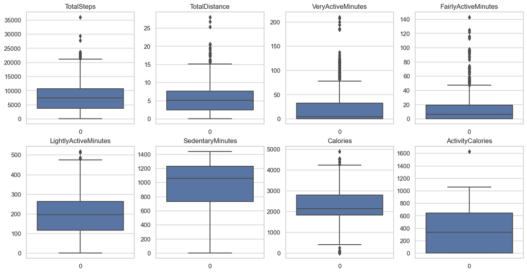

```python
#Looking for outliers with the use of Box plots

#List columns I want to plot
columns_to_plot = ['TotalSteps', 'TotalDistance', 'VeryActiveMinutes', 'FairlyActiveMinutes',
                   'LightlyActiveMinutes', 'SedentaryMinutes', 'Calories', 'ActivityCalories']

# Create a grid of subplots
fig, axes = plt.subplots(nrows=2, ncols=4, figsize=(16, 8))

# Flatten the axes so we can iterate through all the subplots using a single loop instead of two
axes = axes.flatten()

# Plot each boxplot
for i, column in enumerate(columns_to_plot): #use enumerate to get both index and value of each column name
    sns.boxplot(data[column], ax=axes[i])
    axes[i].set_title(column)

# Show the plot
plt.show()
```

All of the variables appear to have some outliers besides sedentary minutes.

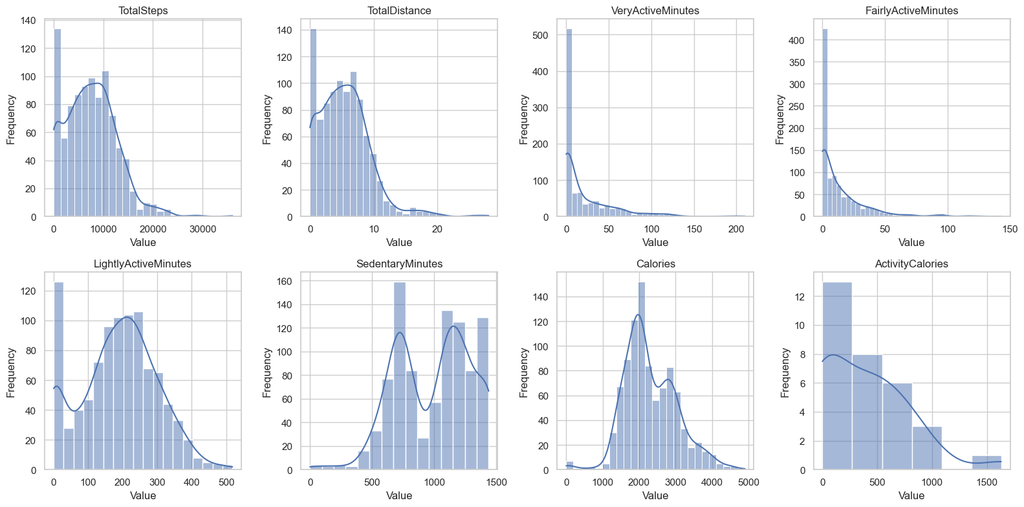

```python
#Looking at the distribution of each variable with histograms

# Create a grid of subplots
fig, axes = plt.subplots(nrows=2, ncols=4, figsize=(16, 8))

# Flatten the axes so we can iterate through all the subplots using a single loop instead of two
axes = axes.flatten()

# Plot each histogram
for i, column in enumerate(columns_to_plot):
    sns.histplot(data[column], ax=axes[i], kde=True)  #kde=True adds a smooth curve to the histograms
    axes[i].set_title(column)
    axes[i].set_xlabel('Value')
    axes[i].set_ylabel('Frequency')


plt.tight_layout() #adjusts padding to prevent overlapping of graph axes

# Show the plot
plt.show()
```

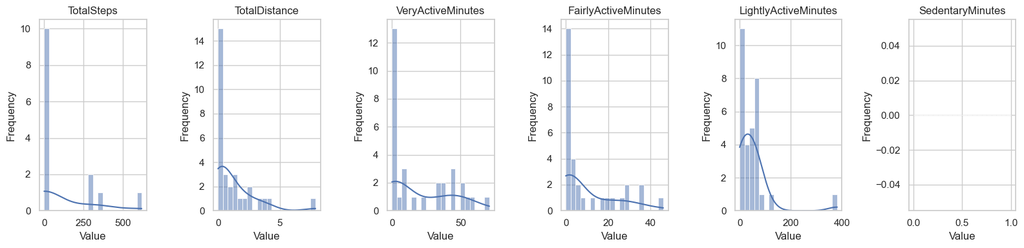

```python
#Histograms for just my data

# Filter the data for "Id" equal to 1 (my ID)
data_id_1 = data[data['Id'] == 1]

#Columns I want to plot
columns_to_plot = ['TotalSteps', 'TotalDistance', 'VeryActiveMinutes', 'FairlyActiveMinutes',
                   'LightlyActiveMinutes', 'SedentaryMinutes']

fig, axes = plt.subplots(1, 6, figsize=(16, 4)) #1 row, 6 plots

# Plot each histogram
for i, column in enumerate(columns_to_plot):
    sns.histplot(data_id_1[column], ax=axes[i], bins=20, kde=True)
    axes[i].set_title(column)
    axes[i].set_xlabel('Value')
    axes[i].set_ylabel('Frequency')

plt.tight_layout() #adjusts padding to prevent overlapping of graph axes

# Show the plots
plt.show()
```

**Data Dictionary:**  
**Variable:** **Type:** **Description:**  
ActivityDate datetime The dates the users' Fitbit data was collected on  
TotalSteps float The number of steps the user took throughout the logged day  
TotalDistance float The total distance the user walked throughout the logged day (in miles)  
VeryActiveMinutes int The number of very active minutes the user had during the logged day  
FairlyActiveMinutes int The number of fairly active minutes the user had during the logged day  
LightlyActiveMinutes int The number of lightly active minutes the user had during the logged day  
SedentaryMinutes float The number of sedentary minutes the user had during the logged day  
Calories float The total number of calories the user burned throughout the logged day  
ActivityCalories float The number of calories the user burned during exercise on the logged day

Note** "Very Active", "Fairly Active", "Lightly Active", and "Sedentary" minutes are categorized by Fitbit metrics

**A list of potential UI components for my dashboard:**

- radio buttons
- date slider
- dropdown
- icons
- white background to keep dashboard clean and make graphs stand out
- use the rule of thirds for the graphs and text
- text with a consistent font

**A list of potential data visualizations for my dashboard:**

- A histogram of the distribution of active minutes for the Fitbit users - with a dropdown to choose "Very", "Fairly", or "Lightly" active minutes
- Animated Plotly bubble chart of total steps for each user (bubble size increases with calories) that has an interaction feature with a date slider
- Line plot to show number of very active minutes over time - with radio button with options of Fitbit users data and my personal data
- Pie chart of my personal data to display the distribution of my physical activity (%very active, %fairly active, %lightly active minutes)
- Scatterplot of Calories burned (x) and number of very active minutes (y) for all Fitbit users